# Clustering — Café Arábica

K-means, Ward.D2 y HDBSCAN · Análisis en R

Juan Sebastián Guayazán · Esteban Valente · Diego Nocua

19 de noviembre de 2026

# Propósito y alcance

Se aplican **K-means**, **clustering jerárquico Ward.D2** y **HDBSCAN** en R a los **1.070 lotes** que pasan el filtro de altitud ($0 < \text{altitud} \le 3.000\text{ m}$). Se conserva el flujo de clase para K-means: estandarizar la matriz $\mathbf{X}$, examinar la suma de cuadrados intra-cluster (WSS) con `factoextra`, fijar $k$ a partir del gráfico del codo, ajustar con 25 inicializaciones aleatorias (`nstart = 25`) y visualizar con `fviz_cluster`.

La elección $k = 3$ se adopta como solución exploratoria elegida visualmente sobre la curva WSS. El índice **Silhouette** se reporta como validación interna y evidencia que la separación geométrica entre grupos es débil. Asimismo, las etiquetas numéricas (`1, 2, 3` o las detectadas por HDBSCAN) no se traducen automáticamente en denominaciones comerciales como *Specialty*, *Premium* o *Commodity* sin definir previamente umbrales externos de calidad. Adicionalmente, se documenta la paridad metodológica con la implementación paralela en Python (`hdbscan_python.py`).

# 1. Preparar datos y PCA exploratorio

Se seleccionan las **8 variables cuantitativas activas** del flujo PCA vigente (`Aroma`, `Flavor`, `Aftertaste`, `Acidity`, `Body`, `Balance`, `Cupper.Points` y `altitude_mean_meters`), excluyendo los conteos de defectos (`Category.One.Defects`, `Category.Two.Defects`), `Moisture` y los atributos sensoriales casi constantes (`Sweetness`, `Uniformity`, `Clean.Cup`), cuya baja dispersión distorsiona la estandarización previa al PCA.

```r
library(dplyr)
library(car)
library(factoextra)
library(fastDummies)
```

```r
library(cluster)
library(ggplot2)
library(knitr)

# HDBSCAN se implementa con el paquete dbscan. Si no está instalado, ejecutar:
# install.packages("dbscan")

data_raw <- read.csv("../data/arabica_data_cleaned.csv")
data_raw$.id_fila <- seq_len(nrow(data_raw))

vars_numericas <- c(
  "Aroma", "Flavor", "Aftertaste", "Acidity", "Body", "Balance",
  "Uniformity", "Clean.Cup", "Sweetness", "Cupper.Points", "Moisture",
  "Category.One.Defects", "Category.Two.Defects", "altitude_mean_meters"
)

datos_filtrados <- data_raw %>%
  filter(!is.na(altitude_mean_meters),
         altitude_mean_meters > 0,
         altitude_mean_meters <= 3000)

# Se conserva la selección de 8 variables activas del PCA vigente.
vars_activas <- setdiff(
  vars_numericas,
  c("Category.One.Defects", "Category.Two.Defects", "Moisture",
    "Sweetness", "Uniformity", "Clean.Cup")
)
datos_originales <- datos_filtrados %>%
  select(.id_fila, all_of(vars_activas))

stopifnot(nrow(datos_originales) == 1070L)
stopifnot(!anyNA(datos_originales[, vars_activas]))

datos_modelo <- datos_originales[, vars_activas, drop = FALSE]

sesgo <- function(x) mean((x - mean(x))^3) / sd(x)^3
sesgo_inicial <- sapply(datos_modelo, sesgo)
vars_transformar <- names(sesgo_inicial[abs(sesgo_inicial) > 1])

cat("Lotes usados:", nrow(datos_modelo), "\n")
```

```
## Lotes usados: 1070
```

```r
cat("Variables PCA activas:", paste(vars_activas, collapse = ", "), "\n")
```

```
## Variables PCA activas: Aroma, Flavor, Aftertaste, Acidity, Body, Balance, Cupper.Points, altitude_mean_meters
```

```r
cat("Variables con |sesgo| > 1:", paste(vars_transformar, collapse = ", "), "\n")
```

```
## Variables con |sesgo| > 1: Aroma, Flavor, Aftertaste, Acidity, Body, Balance, Cupper.Points
```

La transformación de **Yeo-Johnson** se aplica selectivamente siguiendo el criterio del informe PCA actual ($|\text{sesgo}| > 1$), lo que permite manejar valores reales sin restricción estricta de positividad. Se conserva la estimación de máxima verosimilitud de `car::powerTransform` sin forzar parámetros $\lambda$ a rangos arbitrarios.

```r
if (length(vars_transformar) > 0) {
  ajuste_yj <- powerTransform(
    datos_modelo[, vars_transformar, drop = FALSE],
    family = "yjPower"
  )
  lambdas_yj <- coef(ajuste_yj, round = FALSE)
  print(round(lambdas_yj, 3))

  for (v in vars_transformar) {
    datos_modelo[[v]] <- yjPower(datos_modelo[[v]], lambdas_yj[v])
  }
}
```

```
##         Aroma        Flavor    Aftertaste       Acidity          Body
##         3.590         2.739         2.619         3.291         3.079
##       Balance Cupper.Points
##         2.295         2.177
```

```r
sesgo_final <- sapply(datos_modelo, sesgo)
tabla_sesgo <- data.frame(
  Variable = names(sesgo_inicial),
  Sesgo_Inicial = round(as.numeric(sesgo_inicial), 3),
  Transformada_YJ = ifelse(names(sesgo_inicial) %in% vars_transformar, "Sí", "No"),
  Sesgo_Final = round(as.numeric(sesgo_final), 3)
)
kable(tabla_sesgo, caption = "Diagnóstico de asimetría antes y después de Yeo-Johnson (|sesgo| > 1)")
```

Diagnóstico de asimetría antes y después de Yeo-Johnson (|sesgo| > 1)

| Variable | Sesgo_Inicial | Transformada_YJ | Sesgo_Final |
| --- | --- | --- | --- |
| Aroma | -7.218 | Sí | -0.119 |
| Flavor | -6.041 | Sí | -0.474 |
| Aftertaste | -5.636 | Sí | -0.584 |
| Acidity | -6.902 | Sí | -0.122 |
| Body | -8.231 | Sí | -0.400 |
| Balance | -5.405 | Sí | -0.663 |
| Cupper.Points | -3.838 | Sí | -0.424 |
| altitude_mean_meters | -0.827 | No | -0.827 |

```r
pca_exploratorio <- prcomp(datos_modelo, center = TRUE, scale. = TRUE)
var_prop <- pca_exploratorio$sdev^2 / sum(pca_exploratorio$sdev^2)
varianza_acumulada_4pc <- sum(var_prop[1:4])

tabla_pca <- data.frame(
  Componente = paste0("PC", 1:8),
  Desv_Estandar = round(pca_exploratorio$sdev, 3),
  Varianza_Pct = round(var_prop * 100, 2),
  Acumulada_Pct = round(cumsum(var_prop) * 100, 2)
)
kable(tabla_pca, caption = "Descomposición de varianza del PCA exploratorio (1.070 lotes)")
```

Descomposición de varianza del PCA exploratorio (1.070 lotes)

| Componente | Desv_Estandar | Varianza_Pct | Acumulada_Pct |
| --- | --- | --- | --- |
| PC1 | 2.319 | 67.19 | 67.19 |
| PC2 | 0.976 | 11.91 | 79.10 |
| PC3 | 0.650 | 5.28 | 84.38 |
| PC4 | 0.583 | 4.24 | 88.62 |
| PC5 | 0.577 | 4.16 | 92.79 |
| PC6 | 0.498 | 3.10 | 95.88 |
| PC7 | 0.454 | 2.57 | 98.46 |
| PC8 | 0.352 | 1.54 | 100.00 |

```r
cat("Varianza acumulada por las primeras 4 CP:",
    round(varianza_acumulada_4pc * 100, 1), "%\n")
```

```
## Varianza acumulada por las primeras 4 CP: 88.6 %
```

# 2. Variables categóricas y alineación de filas

Se emplean `Processing.Method`, `Color` y `Country.of.Origin`. El país de origen se resume en los **cinco orígenes con mayor número de lotes** más una categoría consolidada `"Otro"`. Cualquier celda vacía o `NA` se codifica explícitamente como `"Desconocido"` (manteniendo intacto el nivel literal `"None"` en `Color`). Se conserva `.id_fila` para garantizar la correspondencia exacta fila a fila entre el bloque numérico PCA y el bloque categórico.

```r
categoricas <- datos_filtrados %>%
  select(.id_fila, Processing.Method, Color, Country.of.Origin) %>%
  mutate(across(
    c(Processing.Method, Color, Country.of.Origin),
    ~ ifelse(is.na(.) | trimws(as.character(.)) == "",
             "Desconocido", trimws(as.character(.)))
  ))

top5_paises <- names(
  sort(table(categoricas$Country.of.Origin), decreasing = TRUE)[1:5]
)
categoricas$Country.of.Origin <- ifelse(
  categoricas$Country.of.Origin %in% top5_paises,
  categoricas$Country.of.Origin,
  "Otro"
)

cat("Top 5 países conservados:", paste(top5_paises, collapse = ", "), "\n")
```

```
## Top 5 países conservados: Mexico, Guatemala, Colombia, Brazil, Taiwan
```

```r
stopifnot(identical(datos_originales$.id_fila, categoricas$.id_fila))
```

```r
datos_categoricos <- categoricas %>%
  select(-.id_fila) %>%
  mutate(across(everything(), factor))

dummies <- model.matrix(
  ~ Processing.Method + Color + Country.of.Origin - 1,
  data = datos_categoricos
)

cat("Filas categóricas:", nrow(dummies), "\n")
```

```
## Filas categóricas: 1070
```

```r
cat("Columnas dummy:", ncol(dummies), "\n")
```

```
## Columnas dummy: 15
```

```r
cat("Filas PCA:", nrow(pca_exploratorio$x), "\n")
```

```
## Filas PCA: 1070
```

```r
stopifnot(nrow(dummies) == nrow(pca_exploratorio$x))
```

# 3. Construir y escalar X

$$X_{\text{num}} =
\frac{Z_{\text{PC1:4}}}{\sqrt{4}}, \qquad X_{\text{dum}} =
\frac{D}{\sqrt{3}}, \qquad \mathbf{X}_{\text{stand}} = \begin{bmatrix}
X_{\text{num}} & X_{\text{dum}} \end{bmatrix}$$

De esta forma, cada componente principal estandarizada aporta una suma de cuadrados de $(n - 1)/4$ (en conjunto $n - 1$ para el bloque numérico) y cada una de las 3 variables categóricas aporta una suma de cuadrados acotada por $n/3$ (en conjunto $\approx n$ para el bloque categórico), sin inflar artificialmente el peso de modalidades poco frecuentes como ocurriría al estandarizar dummies individuales.

```r
X_num <- scale(pca_exploratorio$x[, 1:4, drop = FALSE]) / sqrt(4)
X_dum <- dummies / sqrt(3)
X_stand <- cbind(X_num, X_dum)

cat("Dimensiones de X:", nrow(X_stand), "×", ncol(X_stand), "\n")
```

```
## Dimensiones de X: 1070 × 19
```

```r
cat("Proporción de suma de cuadrados, bloque numérico:",
    round(sum(X_num^2) / sum(X_stand^2) * 100, 1), "%\n")
```

```
## Proporción de suma de cuadrados, bloque numérico: 51.4 %
```

```r
cat("Proporción de suma de cuadrados, bloque categórico:",
    round(sum(X_dum^2) / sum(X_stand^2) * 100, 1), "%\n")
```

```
## Proporción de suma de cuadrados, bloque categórico: 48.6 %
```

# 4. Elegir k con el método del codo

Se evalúa la suma de cuadrados intra-cluster ($\text{WSS} = \sum_{c=1}^{k} \sum_{i \in C_c} \|\mathbf{x}_i - \boldsymbol{\mu}_c\|^2$) para $k = 1, \dots, 5$ con 25 arranques aleatorios por punto. La WSS es monótonamente decreciente con $k$; se inspecciona visualmente el punto de inflexión donde la ganancia marginal comienza a estabilizarse.

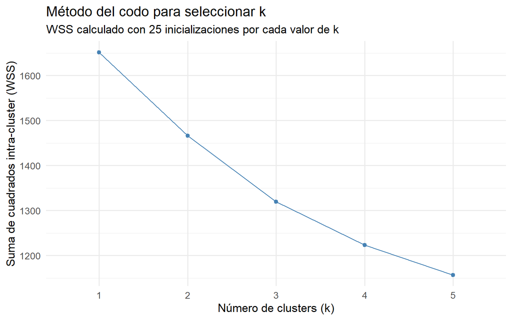

```r
set.seed(42)
grafico_wss <- fviz_nbclust(
  X_stand,
  kmeans,
  method = "wss",
  k.max = 5,
  nstart = 25
) +
  labs(
    title = "Método del codo para seleccionar k",
    subtitle = "WSS calculado con 25 inicializaciones por cada valor de k",
    x = "Número de clusters (k)",
    y = "Suma de cuadrados intra-cluster (WSS)"
  ) +
  theme_minimal(base_size = 13)

grafico_wss
```

La curva reproduciendo esta matriz se aplana gradualmente a partir de $k = 3$. Se fija $k = 3$ como candidato exploratorio de trabajo para caracterizar perfiles y contrastar frente a Ward.D2 y HDBSCAN.

```r
k_optimo <- 3L
cat("k exploratorio seleccionado por inspección de WSS:", k_optimo, "\n")
```

```
## k exploratorio seleccionado por inspección de WSS: 3
```

# 5. K-means

## 5.1 Ajustar y visualizar

Se fija `set.seed(42)` para reproducibilidad completa y se ejecutan 25 inicializaciones (`nstart = 25`), reteniendo la partición con menor WSS total.

```r
set.seed(42)
km <- kmeans(X_stand, centers = k_optimo, nstart = 25)

tabla_tamanos <- as.data.frame(table(cluster = km$cluster))
names(tabla_tamanos)[2] <- "lotes"
tabla_tamanos$porcentaje <- round(100 * tabla_tamanos$lotes / nrow(X_stand), 1)
kable(tabla_tamanos, caption = "Distribución de lotes por cluster en K-means (k = 3)")
```

Distribución de lotes por cluster en K-means (k = 3)

| cluster | lotes | porcentaje |
| --- | --- | --- |
| 1 | 247 | 23.1 |
| 2 | 382 | 35.7 |
| 3 | 441 | 41.2 |

El coeficiente de silueta para cada observación $i$ se define como $s(i) = \frac{b(i) - a(i)}{\max\{a(i), b(i)\}} \in [-1, 1]$, donde $a(i)$ es la distancia media intra-cluster y $b(i)$ es la menor distancia media hacia otro cluster. Valores cercanos a $0$ o negativos revelan solapamiento en la frontera de los grupos.

```r
cat("Varianza explicada entre grupos (BSS/TSS):",
    round(100 * km$betweenss / km$totss, 1), "%\n")
```

```
## Varianza explicada entre grupos (BSS/TSS): 20.1 %
```

```r
sil_km <- silhouette(km$cluster, dist(X_stand))
cat("Silhouette promedio global:",
    round(mean(sil_km[, 3]), 3), "\n")
```

```
## Silhouette promedio global: 0.116
```

```r
cat("Observaciones con Silhouette negativa:",
    sum(sil_km[, 3] < 0), "de", nrow(X_stand),
    sprintf("(%.1f%%)\n", mean(sil_km[, 3] < 0) * 100))
```

```
## Observaciones con Silhouette negativa: 104 de 1070 (9.7%)
```

```r
sil_por_cluster <- aggregate(
  sil_km[, 3],
  by = list(cluster = sil_km[, 1]),
  FUN = mean
)
names(sil_por_cluster)[2] <- "silhouette_promedio"
sil_por_cluster$silhouette_promedio <- round(sil_por_cluster$silhouette_promedio, 3)
kable(sil_por_cluster, caption = "Índice Silhouette promedio por cluster en K-means")
```

Índice Silhouette promedio por cluster en K-means

| cluster | silhouette_promedio |
| --- | --- |
| 1 | 0.088 |
| 2 | 0.168 |
| 3 | 0.086 |

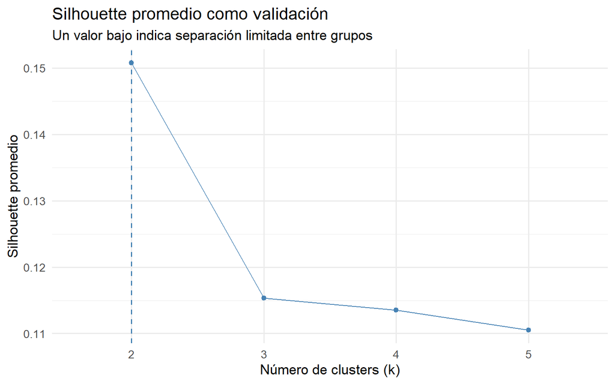

```r
set.seed(42)
fviz_nbclust(
  X_stand,
  kmeans,
  method = "silhouette",
  k.max = 5,
  nstart = 25
) +
  labs(
    title = "Silhouette promedio como validación",
    subtitle = "Un valor bajo indica separación limitada entre grupos",
    x = "Número de clusters (k)",
    y = "Silhouette promedio"
  ) +
  theme_minimal(base_size = 13)
```

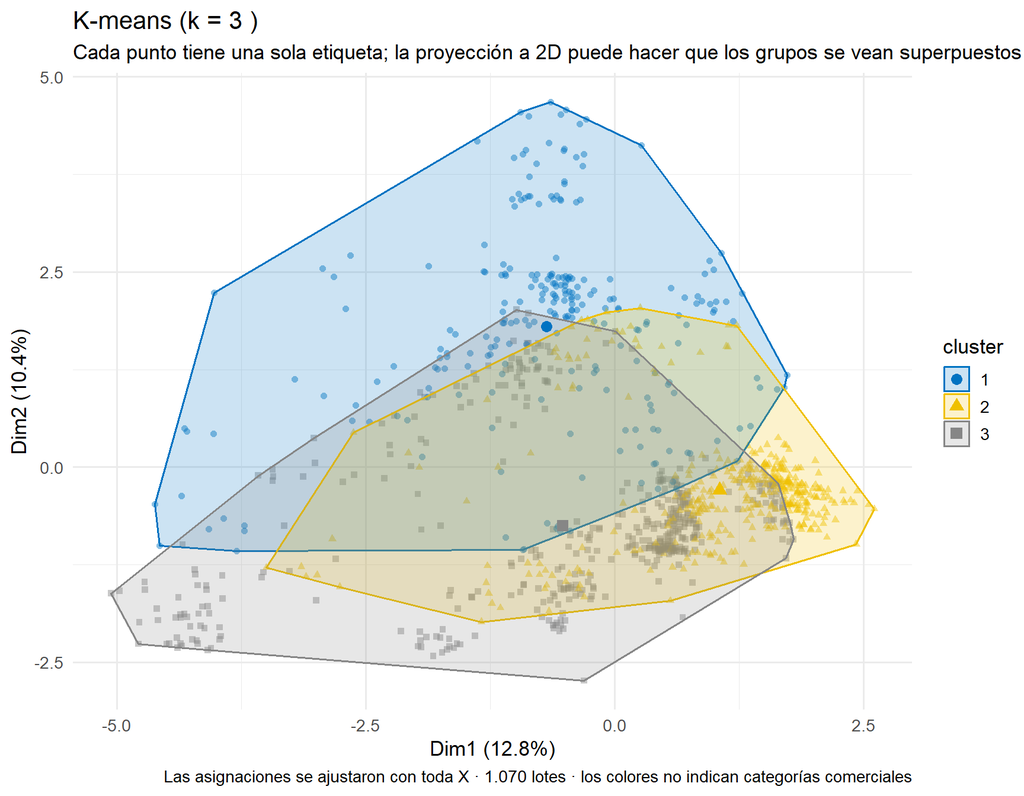

```r
grafico_kmeans <- fviz_cluster(
  km,
  data = X_stand,
  geom = "point",
  ellipse.type = "convex",
  palette = "jco",
  alpha = 0.45,
  ggtheme = theme_minimal()
) +
  labs(
    title = paste("K-means (k =", k_optimo, ")"),
    subtitle = "Cada punto tiene una sola etiqueta; la proyección a 2D puede hacer que los grupos se vean superpuestos",
    caption = "Las asignaciones se ajustaron con toda X · 1.070 lotes · los colores no indican categorías comerciales"
  ) +
  theme_minimal(base_size = 13) +
  theme(
    plot.background = element_rect(fill = "transparent", colour = NA),
    panel.background = element_rect(fill = "transparent", colour = NA),
    legend.background = element_rect(fill = "transparent", colour = NA),
    legend.key = element_rect(fill = "transparent", colour = NA)
  )

dir.create("../imagenes_presentacion",
           recursive = TRUE,
           showWarnings = FALSE)

ggsave(
  "../imagenes_presentacion/kmeans_01_clusters.png",
  plot = grafico_kmeans,
  width = 12,
  height = 5.3,
  dpi = 180,
  bg = "transparent"
)

grafico_kmeans
```

## 5.2 Sensibilidad a la inicialización

Dado que K-means converge a óptimos locales dependientes de los centroides iniciales, se evalúa la estabilidad de la partición de referencia frente a **20 ejecuciones independientes** (cada una con `nstart = 25`) mediante el **Índice Rand Ajustado (ARI)**, donde $\text{ARI} = 1$ indica particiones idénticas salvo permutación de etiquetas.

```r
ari <- function(a, b) {
  tab <- table(a, b)
  choose2 <- function(x) x * (x - 1) / 2
  n <- sum(tab)
  suma_celdas <- sum(choose2(tab))
  suma_filas <- sum(choose2(rowSums(tab)))
  suma_columnas <- sum(choose2(colSums(tab)))
  esperado <- suma_filas * suma_columnas / choose2(n)
  (suma_celdas - esperado) /
    (0.5 * (suma_filas + suma_columnas) - esperado)
}

ari_repeticiones <- numeric(20)
wss_repeticiones <- numeric(20)

for (i in seq_len(20)) {
  set.seed(1000 + i)
  km_i <- kmeans(X_stand, centers = k_optimo, nstart = 25)
  ari_repeticiones[i] <- ari(km$cluster, km_i$cluster)
  wss_repeticiones[i] <- km_i$tot.withinss
}

cat("ARI frente a la solución de referencia — rango:",
    paste(round(range(ari_repeticiones), 3), collapse = " a "), "\n")
```

```
## ARI frente a la solución de referencia — rango: 0.958 a 1
```

```r
cat("WSS entre las 20 repeticiones — rango:",
    paste(round(range(wss_repeticiones), 1), collapse = " a "), "\n")
```

```
## WSS entre las 20 repeticiones — rango: 1319.8 a 1319.8
```

```r
cat("Repeticiones idénticas a la referencia (ARI = 1):",
    sum(ari_repeticiones == 1), "de 20\n")
```

```
## Repeticiones idénticas a la referencia (ARI = 1): 16 de 20
```

## 5.3 Perfil en las variables originales

Las asignaciones de K-means se cruzan con las variables originales en escala de catación Q-Grader y altitud para describir el comportamiento promedio de cada grupo. `Total.Cup.Points` se emplea exclusivamente como variable descriptiva externa, nunca como entrada del algoritmo.

```r
datos_perfil_km <- datos_filtrados %>%
  select(.id_fila, all_of(vars_numericas), Total.Cup.Points) %>%
  mutate(cluster = factor(km$cluster))

perfil_km <- datos_perfil_km %>%
  group_by(cluster) %>%
  summarise(
    lotes = n(),
    porcentaje = round(100 * n() / nrow(datos_perfil_km), 1),
    Aroma = round(mean(Aroma), 2),
    Flavor = round(mean(Flavor), 2),
    Aftertaste = round(mean(Aftertaste), 2),
    Acidity = round(mean(Acidity), 2),
    Body = round(mean(Body), 2),
    Balance = round(mean(Balance), 2),
    Cupper.Points = round(mean(Cupper.Points), 2),
    Total.Cup.Points = round(mean(Total.Cup.Points), 2),
    Altitud_m = round(mean(altitude_mean_meters), 0),
    .groups = "drop"
  )

kable(perfil_km, caption = "Perfil sensorial y altitudinal promedio por cluster (escala original)")
```

Perfil sensorial y altitudinal promedio por cluster (escala original)

| cluster | lotes | porcentaje | Aroma | Flavor | Aftertaste | Acidity | Body | Balance | Cupper.Points | Total.Cup.Points | Altitud_m |
| --- | --- | --- | --- | --- | --- | --- | --- | --- | --- | --- | --- |
| 1 | 247 | 23.1 | 7.61 | 7.59 | 7.46 | 7.52 | 7.56 | 7.55 | 7.57 | 82.63 | 780 |
| 2 | 382 | 35.7 | 7.39 | 7.28 | 7.11 | 7.37 | 7.30 | 7.23 | 7.16 | 80.12 | 1302 |
| 3 | 441 | 41.2 | 7.70 | 7.68 | 7.60 | 7.67 | 7.65 | 7.72 | 7.72 | 83.61 | 1601 |

No se asignan las etiquetas *Specialty*, *Premium* o *Commodity* de manera automática desde el algoritmo: para sustentar dichas categorías se requieren reglas de corte externas (por ejemplo, el umbral de 80 puntos SCA) definidas antes del agrupamiento.

# 6. Clustering jerárquico Ward.D2

El algoritmo aglomerativo **Ward.D2** fusiona en cada paso el par de grupos que produce el menor incremento en la suma de cuadrados intra-cluster (criterio de mínima varianza sobre distancias euclídeas). Se emplea una muestra aleatoria reproducible de **80 lotes** para garantizar la legibilidad visual del dendrograma, cortando el árbol en $k = 3$.

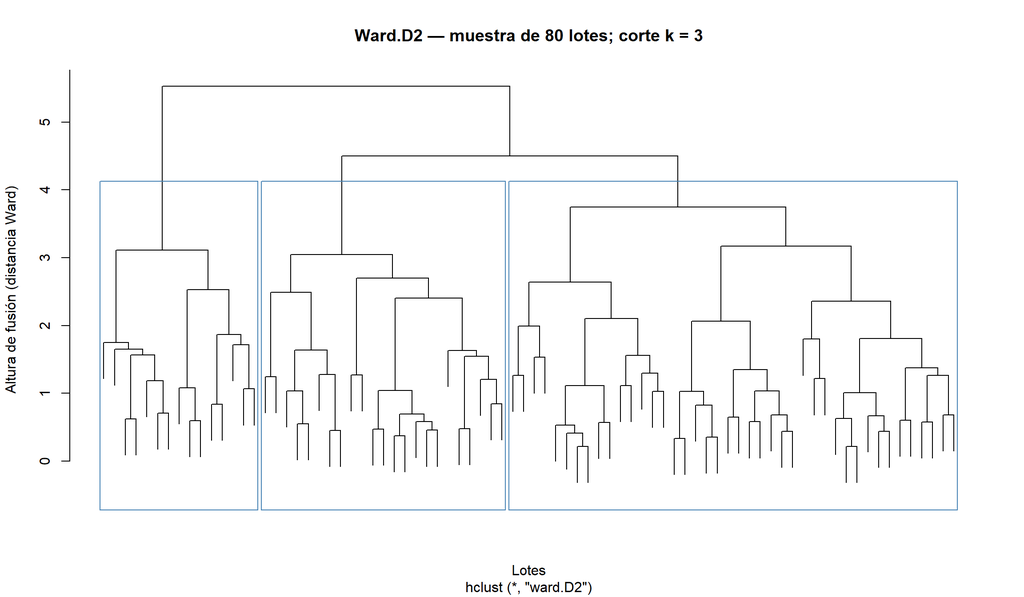

```r
set.seed(42)
idx_ward <- sample(seq_len(nrow(X_stand)), 80)
X_ward <- X_stand[idx_ward, , drop = FALSE]

hc_ward <- hclust(dist(X_ward), method = "ward.D2")
grupos_ward <- cutree(hc_ward, k = k_optimo)

plot(
  hc_ward,
  labels = FALSE,
  main = paste("Ward.D2 — muestra de 80 lotes; corte k =", k_optimo),
  xlab = "Lotes",
  ylab = "Altura de fusión (distancia Ward)"
)
rect.hclust(hc_ward, k = k_optimo, border = "steelblue")
```

```r
cat("Tamaño de los grupos Ward en la muestra:\n")
```

```
## Tamaño de los grupos Ward en la muestra:
```

```r
print(table(grupos_ward))
```

```
## grupos_ward
##  1  2  3
## 15 42 23
```

Dado que Ward.D2 se ajusta aquí sobre una submuestra de 80 lotes mientras K-means opera sobre los 1.070 lotes completos, el dendrograma cumple una función ilustrativa de la jerarquía aglomerativa y no debe equipararse directamente a una partición poblacional.

# 7. HDBSCAN: clustering jerárquico basado en densidad

**HDBSCAN** (*Hierarchical Density-Based Spatial Clustering of Applications with Noise*) estima la densidad local mediante distancias al $k$-ésimo vecino más cercano (*core distances*), construye un árbol de expansión mínima sobre distancias de alcanzabilidad mutua y extrae los grupos más persistentes a través de escalas de densidad. A diferencia de K-means y Ward.D2:

- **No requiere prefijar $k$:** el número de clusters emerge de la estructura de densidad.
- **Identifica ruido explícito (etiqueta `0` en R, `-1` en Python):** las observaciones ubicadas en regiones dispersas o de transición no son forzadas a pertenecer a ningún grupo.
- **Permite formas no convexas** y densidades heterogéneas entre grupos.

## 7.1 Ajuste base con `minPts = 10` y perfiles

Se aplica `dbscan::hdbscan` sobre la misma matriz ponderada `X_stand` de 1.070 lotes utilizando `minPts = 10` como punto de partida exploratorio.

```r
if (!requireNamespace("dbscan", quietly = TRUE)) {
  stop("Falta el paquete 'dbscan'. Instálalo ejecutando install.packages('dbscan') y vuelve a tejer el Rmd.")
}

minPts_hdbscan <- 10L
hdb <- dbscan::hdbscan(X_stand, minPts = minPts_hdbscan)

# La etiqueta 0 representa observaciones consideradas ruido por HDBSCAN.
cluster_hdb <- hdb$cluster
n_clusters_hdb <- length(setdiff(unique(cluster_hdb), 0))
n_ruido_hdb <- sum(cluster_hdb == 0)

resumen_hdbscan <- data.frame(
  Metodo = "HDBSCAN",
  minPts = minPts_hdbscan,
  Lotes = length(cluster_hdb),
  Clusters = n_clusters_hdb,
  Ruido = n_ruido_hdb,
  Porcentaje_ruido = round(100 * n_ruido_hdb / length(cluster_hdb), 1)
)

kable(resumen_hdbscan, caption = "Resumen global del modelo HDBSCAN (minPts = 10)")
```

Resumen global del modelo HDBSCAN (minPts = 10)

| Metodo | minPts | Lotes | Clusters | Ruido | Porcentaje_ruido |
| --- | --- | --- | --- | --- | --- |
| HDBSCAN | 10 | 1070 | 6 | 610 | 57 |

```r
cat("Tamaño de los grupos (incluye 0 = ruido):\n")
```

```
## Tamaño de los grupos (incluye 0 = ruido):
```

```r
print(sort(table(cluster_hdb), decreasing = TRUE))
```

```
## cluster_hdb
##   0   6   5   4   3   2   1
## 610 134 110 108  67  30  11
```

## 7.2 Visualización y caracterización de clusters HDBSCAN

```r
pca_grafico_hdb <- prcomp(X_stand, center = FALSE, scale. = FALSE)

datos_grafico_hdb <- data.frame(
  PC1 = pca_grafico_hdb$x[, 1],
  PC2 = pca_grafico_hdb$x[, 2],
  Cluster = factor(cluster_hdb, levels = sort(unique(cluster_hdb))),
  Tipo = ifelse(cluster_hdb == 0, "Ruido", "Cluster")
)

# Asignar gris al ruido y una paleta diferenciada a los clusters detectados.
niveles_cluster_hdb <- levels(datos_grafico_hdb$Cluster)
clusters_reales_hdb <- setdiff(niveles_cluster_hdb, "0")
colores_hdb <- setNames(
  grDevices::hcl.colors(length(clusters_reales_hdb), palette = "Dark 3"),
  clusters_reales_hdb
)
if ("0" %in% niveles_cluster_hdb) {
  colores_hdb <- c(colores_hdb, "0" = "grey65")
}

# Ordenar para que los puntos de ruido queden visibles por encima de los grupos.
datos_grafico_hdb <- datos_grafico_hdb[order(datos_grafico_hdb$Tipo), ]

grafico_hdbscan <- ggplot(
  datos_grafico_hdb,
  aes(x = PC1, y = PC2, color = Cluster)
) +
  geom_point(alpha = 0.65, size = 2) +
  scale_color_manual(values = colores_hdb, name = "Cluster (0 = ruido)") +
  labs(
    title = "HDBSCAN — agrupamiento basado en densidad",
    subtitle = paste0(
      n_clusters_hdb, " clusters identificados · ", n_ruido_hdb,
      " observaciones clasificadas como ruido · minPts = ", minPts_hdbscan
    ),
    x = "Componente principal 1",
    y = "Componente principal 2",
    caption = "HDBSCAN se ajustó en la matriz X completa; el gráfico muestra una proyección PCA a 2D"
  ) +
  theme_minimal(base_size = 13) +
  theme(
    plot.background = element_rect(fill = "transparent", colour = NA),
    panel.background = element_rect(fill = "transparent", colour = NA),
    legend.background = element_rect(fill = "transparent", colour = NA),
    legend.key = element_rect(fill = "transparent", colour = NA)
  )

dir.create("../imagenes_presentacion", recursive = TRUE, showWarnings = FALSE)

ggsave(
  "../imagenes_presentacion/hdbscan_01_clusters.png",
  plot = grafico_hdbscan,
  width = 12,
  height = 5.3,
  dpi = 180,
  bg = "transparent"
)

perfil_hdb <- datos_filtrados %>%
  mutate(cluster_hdb = factor(cluster_hdb)) %>%
  group_by(cluster_hdb) %>%
  summarise(
    lotes = n(),
    porcentaje = round(100 * n() / nrow(datos_filtrados), 1),
    puntaje_prom = round(mean(Total.Cup.Points, na.rm = TRUE), 2),
    altitud_prom = round(mean(altitude_mean_meters, na.rm = TRUE), 0),
    pais_top = names(which.max(table(Country.of.Origin))),
    proceso_top = names(which.max(table(Processing.Method))),
    .groups = "drop"
  )

kable(perfil_hdb, caption = "Perfil de los clusters HDBSCAN (0 = ruido) en variables originales")
```

Perfil de los clusters HDBSCAN (0 = ruido) en variables originales

| cluster_hdb | lotes | porcentaje | puntaje_prom | altitud_prom | pais_top | proceso_top |
| --- | --- | --- | --- | --- | --- | --- |
| 0 | 610 | 57.0 | 82.19 | 1226 | Mexico | Washed / Wet |
| 1 | 11 | 1.0 | 82.41 | 1466 | Honduras | Natural / Dry |
| 2 | 30 | 2.8 | 82.53 | 958 | Brazil | Natural / Dry |
| 3 | 67 | 6.3 | 83.34 | 1730 | Colombia | Washed / Wet |
| 4 | 108 | 10.1 | 80.75 | 1249 | Mexico | Washed / Wet |
| 5 | 110 | 10.3 | 82.02 | 1425 | Guatemala | Washed / Wet |
| 6 | 134 | 12.5 | 82.43 | 1459 | Tanzania, United Republic Of | Washed / Wet |

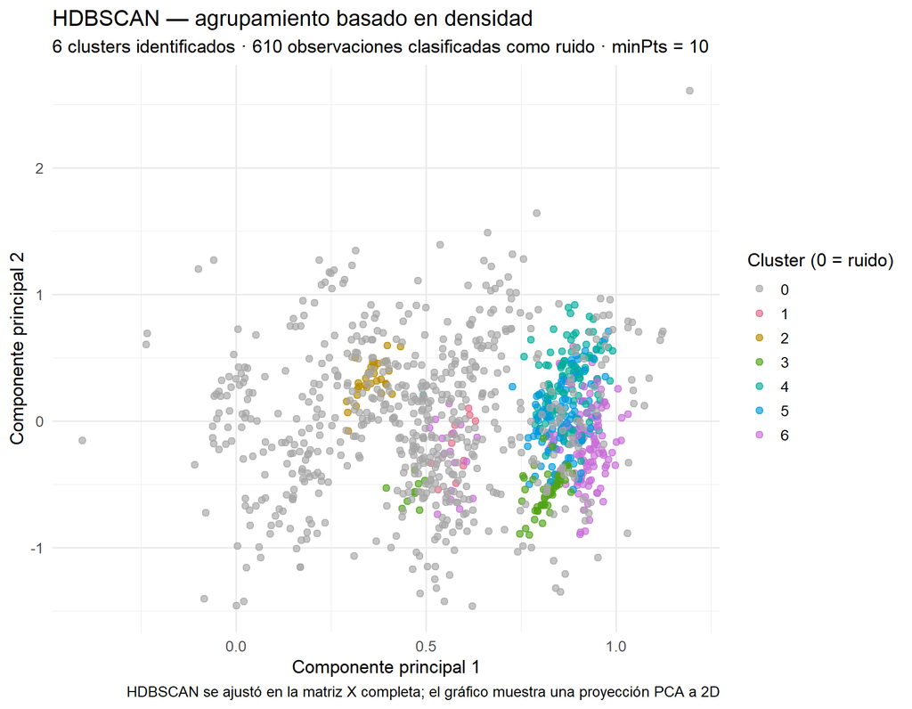

```r
grafico_hdbscan
```

## 7.3 Validación interna y sensibilidad de `minPts`

El índice Silhouette de HDBSCAN se calcula excluyendo las observaciones etiquetadas como ruido (`0`), dado que el ruido no conforma un grupo cohesionado. Además, se reporta la probabilidad promedio de pertenencia (`membership_prob`) de los lotes asignados y se evalúa la sensibilidad del agrupamiento al variar `minPts` $\in \{5, 10, 15\}$.

```r
idx_asignados_hdb <- which(cluster_hdb != 0)
clusters_asignados_hdb <- cluster_hdb[idx_asignados_hdb]

if (length(unique(clusters_asignados_hdb)) >= 2 &&
    length(idx_asignados_hdb) >= 3) {
  sil_hdb <- cluster::silhouette(
    clusters_asignados_hdb,
    dist(X_stand[idx_asignados_hdb, , drop = FALSE])
  )
  silhouette_hdb_prom <- mean(sil_hdb[, 3])
  cat("Silhouette promedio (sin ruido):",
      round(silhouette_hdb_prom, 3), "\n")
} else {
  sil_hdb <- NULL
  silhouette_hdb_prom <- NA_real_
  cat("Silhouette no disponible: se requieren al menos dos clusters no vacíos.\n")
}
```

```
## Silhouette promedio (sin ruido): 0.305
```

```r
cat("Porcentaje de ruido:",
    round(100 * mean(cluster_hdb == 0), 1), "%\n")
```

```
## Porcentaje de ruido: 57 %
```

```r
if (any(cluster_hdb != 0)) {
  cat("Probabilidad de pertenencia promedio:",
      round(mean(hdb$membership_prob[cluster_hdb != 0], na.rm = TRUE), 3), "\n")
} else {
  cat("No hay observaciones asignadas a clusters; no se calcula probabilidad promedio.\n")
}
```

```
## Probabilidad de pertenencia promedio: 0.308
```

```r
# Barrido exploratorio de sensibilidad sobre minPts
sensibilidad_hdb <- lapply(c(5L, 10L, 15L), function(mp) {
  mod_mp <- dbscan::hdbscan(X_stand, minPts = mp)
  cl_mp <- mod_mp$cluster
  n_cl <- length(setdiff(unique(cl_mp), 0))
  pct_ruido <- round(100 * mean(cl_mp == 0), 1)
  idx_asig <- which(cl_mp != 0)
  sil_val <- if (n_cl >= 2 && length(idx_asig) >= 3) {
    round(mean(cluster::silhouette(cl_mp[idx_asig], dist(X_stand[idx_asig, , drop = FALSE]))[, 3]), 3)
  } else {
    NA_real_
  }
  data.frame(
    minPts = mp,
    Clusters_detectados = n_cl,
    Lotes_asignados = length(idx_asig),
    Porcentaje_ruido = pct_ruido,
    Silhouette_sin_ruido = sil_val
  )
}) %>% bind_rows()

kable(sensibilidad_hdb, caption = "Análisis de sensibilidad de HDBSCAN frente al parámetro minPts")
```

Análisis de sensibilidad de HDBSCAN frente al parámetro minPts

| minPts | Clusters_detectados | Lotes_asignados | Porcentaje_ruido | Silhouette_sin_ruido |
| --- | --- | --- | --- | --- |
| 5 | 17 | 639 | 40.3 | 0.248 |
| 10 | 6 | 460 | 57.0 | 0.305 |
| 15 | 5 | 427 | 60.1 | 0.333 |

## 7.4 Paridad y validación cruzada en Python (`hdbscan_python.py`)

Como verificación independiente de reproducibilidad entre entornos, se implementó el script autónomo `04-clustering/hdbscan_python.py` (`scikit-learn` + `hdbscan`, con parámetros equivalentes `min_cluster_size = 10` y `min_samples = 10`). Para garantizar la paridad exacta con la matriz `X_stand` de R, la implementación en Python incorpora tres controles técnicos específicos:

1. **Preservación de la categoría literal `"None"` en `Color`:** se lee el CSV con `keep_default_na=False` y `na_values=["", "NA", "N/A"]` para impedir que `pandas` convierta `"None"` en `NaN` y lo fusione erróneamente con `"Desconocido"`.
2. **Transformación Yeo-Johnson sin re-estandarización interna:** se utiliza `PowerTransformer(method="yeo-johnson", standardize=False)` sobre las variables con $|\text{sesgo}| > 1$ antes de aplicar `StandardScaler` y PCA completo (`svd_solver="full"`, 4 componentes escaladas y divididas por $\sqrt{4}$).
3. **Alineación exacta de contrastes categóricos:** a partir de `OneHotEncoder`, se conservan todos los indicadores de `Processing.Method` y se omite el primer nivel ordenado alfabéticamente en `Color` y `Country.of.Origin`, replicando con exactitud `model.matrix(~ Processing.Method + Color + Country.of.Origin - 1)` de R antes de ponderar por $1/\sqrt{3}$.

Además de los tamaños (`hdbscan_tamanos.csv`) y el gráfico en el plano `PC1-PC2` (`hdbscan_clusters.png`), el flujo en Python exporta por cada lote (`hdbscan_resultados.csv`) la probabilidad de pertenencia y el índice GLOSH (`outlier_score`), permitiendo auditar qué lotes marginales contribuyen al porcentaje de ruido.

# 8. Comparación global de métodos (K-means, Ward.D2 y HDBSCAN)

```r
ari_km_ward <- ari(km$cluster[idx_ward], grupos_ward)
sil_ward <- silhouette(grupos_ward, dist(X_ward))

resumen_metodos <- data.frame(
  Metodo = c("K-means", "Ward.D2", "HDBSCAN"),
  Lotes_ajustados = c(nrow(X_stand), length(idx_ward), nrow(X_stand)),
  Clusters = c(k_optimo, length(unique(grupos_ward)), n_clusters_hdb),
  Silhouette_promedio = round(c(
    mean(sil_km[, 3]),
    mean(sil_ward[, 3]),
    silhouette_hdb_prom
  ), 3),
  Manejo_Ruido = c(
    "No (asigna el 100% de lotes)",
    "No (asigna el 100% de la muestra)",
    paste0("Sí (", round(100 * mean(cluster_hdb == 0), 1), "% clasificado como ruido)")
  ),
  Nota = c(
    "Todos los lotes; silhouette en X completa",
    "Muestra de 80; silhouette en la submuestra",
    "Todos los lotes; silhouette calculada sin ruido"
  )
)

kable(resumen_metodos, caption = "Síntesis comparativa entre K-means, Ward.D2 y HDBSCAN")
```

Síntesis comparativa entre K-means, Ward.D2 y HDBSCAN

| Metodo | Lotes_ajustados | Clusters | Silhouette_promedio | Manejo_Ruido | Nota |
| --- | --- | --- | --- | --- | --- |
| K-means | 1070 | 3 | 0.116 | No (asigna el 100% de lotes) | Todos los lotes; silhouette en X completa |
| Ward.D2 | 80 | 3 | 0.128 | No (asigna el 100% de la muestra) | Muestra de 80; silhouette en la submuestra |
| HDBSCAN | 1070 | 6 | 0.305 | Sí (57% clasificado como ruido) | Todos los lotes; silhouette calculada sin ruido |

```r
cat("ARI K-means / Ward.D2 en la muestra de 80 lotes:", round(ari_km_ward, 3), "\n")
```

```
## ARI K-means / Ward.D2 en la muestra de 80 lotes: 0.471
```

Las métricas de Ward se restringen a una muestra de 80 y no son directamente comparables con las de K-means sobre los 1.070 lotes. Tanto K-means como Ward.D2 emplean distancia euclídea global y tienden a particionar el espacio en regiones convexas compactas obligando a asignar incluso los lotes periféricos, mientras que HDBSCAN privilegia núcleos densos homogéneos (fuertemente estructurados por combinaciones de país de origen y método de beneficio) y aísla como ruido los lotes atípicos o de transición.

# 9. Conclusión